# 印度新冠肺炎疫情中疫苗效果的实证分析——基于干预分析和协整模型的分析与预测

# 数据预处理

```r
dat <- read.csv("F:/时间序列分析/时序期末/covid_19_india.csv")[,-c(1,3,4)]
ill <- data.frame(aggregate(dat[,4:6],list(dat[,1]),sum))
ill <- ill[-c(1:45),]
cured <- ts(diff(ill[,2])[-c(1:4)],frequency = 7)
confirmed <- ts(diff(ill[,4])[-c(1:4)],frequency = 7)
death <- ts(diff(ill[,3])[-c(1:4)],frequency = 7)
dat1 <- read.csv("F:/时间序列分析/时序期末/covid_vaccine_statewise.csv")
dat1[,1] <- as.Date(dat1[,1],"%d/%m/%Y")
dat1 <- dat1[order(dat1$Updated.On),]
dat1 <- dat1[-which(dat1$Updated.On=="2021-06-08"),]
dat1 <- na.omit(dat1[,1:12])
vaccinated <- data.frame(aggregate(as.numeric(dat1[,3]),list(dat1[,1]),sum))
vaccinated <- vaccinated[order(vaccinated$Group.1),2]
male <- data.frame(aggregate(as.numeric(dat1[,8]),list(dat1[,1]),sum))
male <- male[order(male$Group.1),2]
female <- data.frame(aggregate(as.numeric(dat1[,9]),list(dat1[,1]),sum))
female <- female[order(female$Group.1),2]
transgender <- data.frame(aggregate(as.numeric(dat1[,10]),list(dat1[,1]),sum))
transgender <- transgender[order(transgender$Group.1),2]
```

# 印度新冠疫情新增确诊数据序列拟合

## 平稳性检验

```r
library(aTSA)
library(forecast)
#进行一周的周期差分和一阶差分后序列平稳
adf.test(diff(diff(confirmed,7)))
```

```
## Augmented Dickey-Fuller Test
## alternative: stationary
##
## Type 1: no drift no trend
##      lag    ADF p.value
## [1,]   0 -31.36    0.01
## [2,]   1 -19.49    0.01
## [3,]   2 -10.93    0.01
## [4,]   3  -8.76    0.01
## [5,]   4  -7.77    0.01
## [6,]   5  -4.61    0.01
## Type 2: with drift no trend
##      lag    ADF p.value
## [1,]   0 -31.33    0.01
## [2,]   1 -19.47    0.01
## [3,]   2 -10.93    0.01
## [4,]   3  -8.76    0.01
## [5,]   4  -7.77    0.01
## [6,]   5  -4.60    0.01
## Type 3: with drift and trend
##      lag    ADF p.value
## [1,]   0 -31.32    0.01
## [2,]   1 -19.48    0.01
## [3,]   2 -10.94    0.01
## [4,]   3  -8.76    0.01
## [5,]   4  -7.78    0.01
## [6,]   5  -4.58    0.01
## ----
## Note: in fact, p.value = 0.01 means p.value <= 0.01
```

## 拟合确诊人数序列

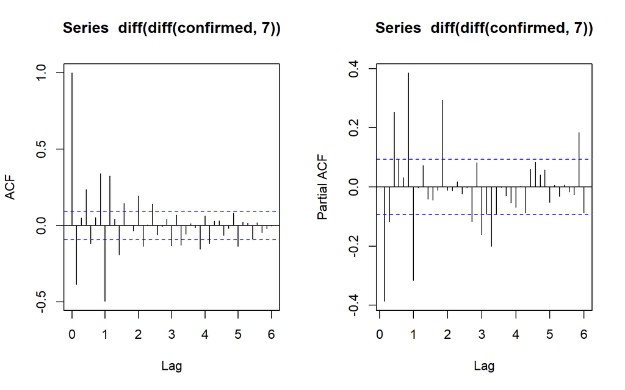

```r
par(mfrow=c(1,2))
acf(diff(diff(confirmed,7)),lag=42)
pacf(diff(diff(confirmed,7)),lag=42)
```

趋势：acf拖尾，pacf拖尾——ARIMA(1,1,1)

季节：acf拖尾，pacf拖尾——ARIMA(1,1,1)

```r
#通过观察系数显著性，对模型进行升阶改进，最终选择如下模型：
fit1 <- arima(confirmed,order = c(3,1,5),seasonal=list(order=c(1,1,1),period=7));fit1
```

```
##
## Call:
## arima(x = confirmed, order = c(3, 1, 5), seasonal = list(order = c(1, 1, 1),
##     period = 7))
##
## Coefficients:
##          ar1      ar2     ar3      ma1     ma2      ma3     ma4     ma5
##       1.9230  -1.8264  0.8264  -2.1954  2.5078  -1.4844  0.3372  0.1253
## s.e.  0.0481   0.0754  0.0487   0.0702  0.1567   0.1943  0.1435  0.0649
##          sar1     sma1
##       -0.2695  -0.6323
## s.e.   0.0834   0.0694
##
## sigma^2 estimated as 33613664:  log likelihood = -4419.3,  aic = 8860.6
```

随后对模型进行检验：

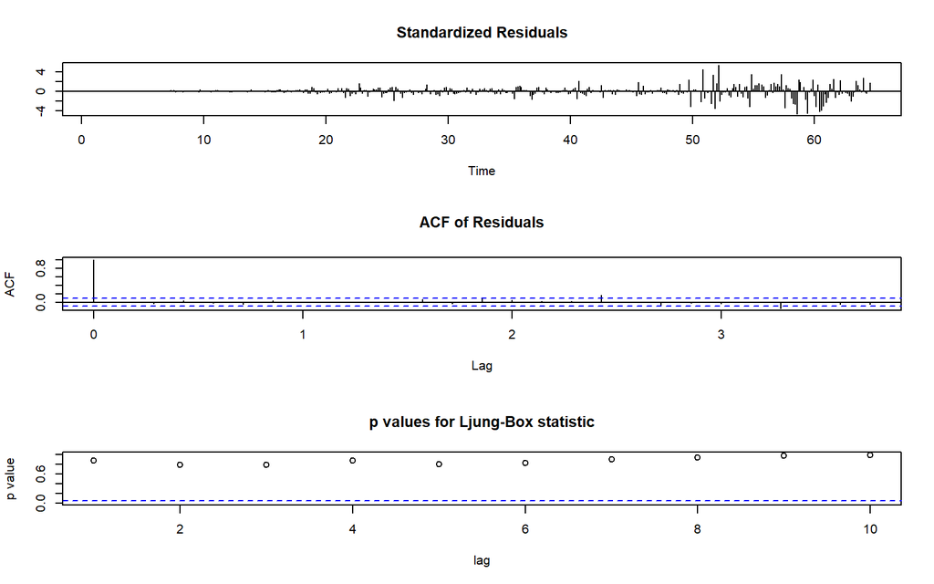

```r
tsdiag(fit1)
```

可以发现整体模型也是显著的，进一步尝试进行预测效果验证和最终预测。

## 预测效果交叉验证

```r
mape <- vector()
smape <- vector()
for(i in 4:1){
print(c((438+2*i-1):(438+2*i)))
fit3.1 <- Arima(confirmed[-c((438+2*i-1):(438+2*i))],order = c(3,1,5),seasonal=list(order=c(1,1,1),period=7))
forenew<-forecast::forecast(fit3.1,h=7)
#平均绝对百分比误差(MAPE, Mean Absolute Percentage Error)
mape <- c(mape,mean(abs((forenew$mean-confirmed[c((438+2*i-1):(438+2*i))]))/confirmed[c((438+2*i-1):(438+2*i))]))
print(mean(abs((forenew$mean-confirmed[c((438+2*i-1):(438+2*i))]))/confirmed[c((438+2*i-1):(438+2*i))]))
#SMAPE
smape <- c(smape,2*(mean(abs(forenew$mean-confirmed[c((438+2*i-1):(438+2*i))])/(abs(forenew$mean)+abs(confirmed[c((438+2*i-1):(438+2*i))])))))
print(2*(mean(abs(forenew$mean-confirmed[c((438+2*i-1):(438+2*i))])/(abs(forenew$mean)+abs(confirmed[c((438+2*i-1):(438+2*i))])))))
}
```

```
## [1] 445 446
## [1] 0.1538729
## [1] 0.1724206
## [1] 443 444
## [1] 0.6868284
## [1] 1.105529
## [1] 441 442
## [1] 0.7506728
## [1] 1.249978
## [1] 439 440
## [1] 0.7274339
## [1] 1.190007
```

```r
cat("MAPE",mean(mape))
```

```
## MAPE 0.579702
```

```r
cat(" SMAPE",mean(smape))
```

```
##  SMAPE 0.9294839
```

关注到交叉验证计算的MAPE和SMAPE的均小于1.5，且均值均小于1，说明模型的预测效果虽然尚佳但是均值却大于0.5，仍然具有预测效果提升的必要性。

## 疫情走势预测

```r
forenew<-forecast::forecast(fit1,h=5);forenew
```

```
##          Point Forecast    Lo 80    Hi 80    Lo 95    Hi 95
## 64.71429       94157.06 86726.97 101587.1 82793.72 105520.4
## 64.85714      103148.02 93959.30 112336.7 89095.08 117201.0
## 65.00000       93326.75 82027.15 104626.3 76045.50 110608.0
## 65.14286       91085.31 77448.48 104722.1 70229.58 111941.0
## 65.28571       87543.33 71545.73 103540.9 63077.11 112009.5
```

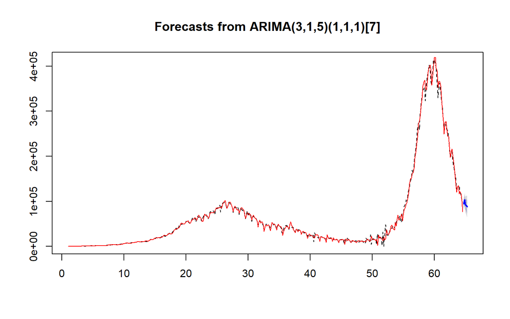

```r
plot(forenew,lty=2)
lines(forenew$fitted,col=2)
```

# 印度疫情干预分析

## 普及疫苗政策对于新增确诊人数的影响

```r
vaccinated <- ts(c(rep(0,304),diff(vaccinated)),frequency = 7)
#summary(vaccinated)
male <- ts(c(rep(0,303),male),frequency = 7)
female <- ts(c(rep(0,303),female),frequency = 7)
transgender <- ts(c(rep(0,303),transgender),frequency = 7)

law <- c(rep(0,301),rep(1,145))
fit2 <- arima(confirmed,xreg = as.matrix(data.frame(law)),order = c(3,1,5),seasonal=list(order=c(1,1,1),period=7));fit2
```

```
##
## Call:
## arima(x = confirmed, order = c(3, 1, 5), seasonal = list(order = c(1, 1, 1),
##     period = 7), xreg = as.matrix(data.frame(law)))
##
## Coefficients:
##          ar1      ar2     ar3      ma1     ma2      ma3     ma4     ma5
##       1.9229  -1.8262  0.8263  -2.1952  2.5073  -1.4844  0.3376  0.1251
## s.e.  0.0482   0.0756  0.0488   0.0703  0.1570   0.1943  0.1435  0.0649
##          sar1     sma1        law
##       -0.2699  -0.6320  -421.2485
## s.e.   0.0836   0.0695  4173.9657
##
## sigma^2 estimated as 33613156:  log likelihood = -4419.3,  aic = 8862.59
```

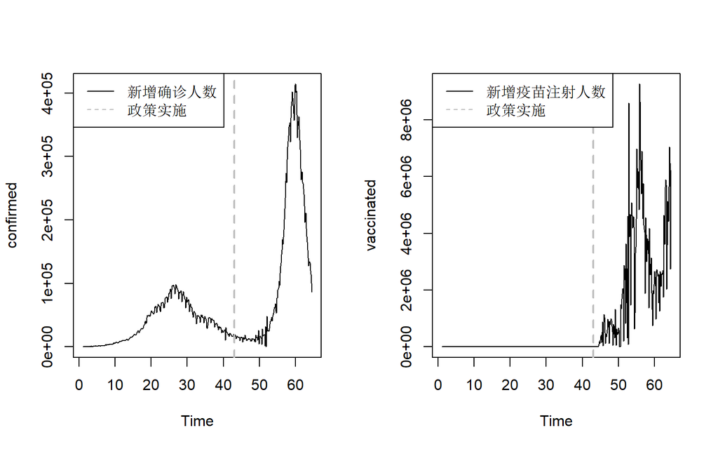

```r
par(mfrow=c(1,2))
plot(confirmed)
abline(v = 43, col = "gray", lwd = 2, lty = 2)
legend("topleft",c("新增确诊人数","政策实施"), col = c("black","gray"),lty = c(1,2))
plot(vaccinated)
abline(v = 43, col = "gray", lwd = 2, lty = 2)
legend("topleft",c("新增疫苗注射人数","政策实施"), col = c("black","gray"),lty = c(1,2))
```

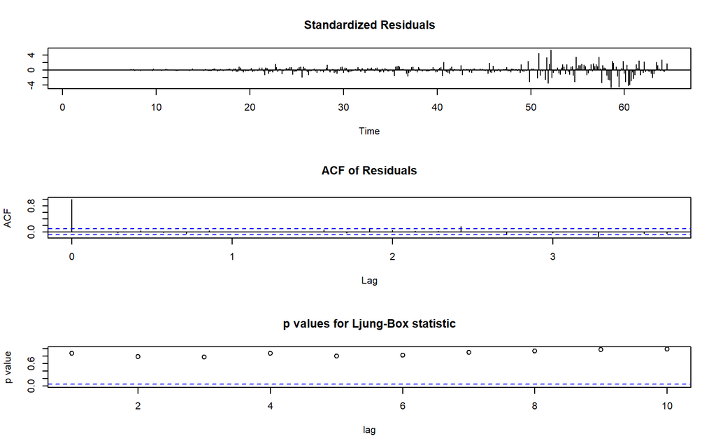

```r
tsdiag(fit2)
```

整体模型同样显著，但不能说明新冠疫苗注射的普及对于疫情防控有显著促进，即当时的政策并未产生充分积极的影响，国民没有立刻响应号召。

# 考虑使用实际注射疫苗数据作为自变量

## 模型拟合

```r
fit <- lm(confirmed~male+transgender+vaccinated+cured+death)
adf.test(fit$residuals)
```

```
## Augmented Dickey-Fuller Test
## alternative: stationary
##
## Type 1: no drift no trend
##      lag   ADF p.value
## [1,]   0 -4.94    0.01
## [2,]   1 -3.51    0.01
## [3,]   2 -3.31    0.01
## [4,]   3 -3.48    0.01
## [5,]   4 -2.79    0.01
## [6,]   5 -2.77    0.01
## Type 2: with drift no trend
##      lag   ADF p.value
## [1,]   0 -4.94  0.0100
## [2,]   1 -3.50  0.0100
## [3,]   2 -3.29  0.0172
## [4,]   3 -3.46  0.0100
## [5,]   4 -2.78  0.0652
## [6,]   5 -2.76  0.0690
## Type 3: with drift and trend
##      lag   ADF p.value
## [1,]   0 -4.93  0.0100
## [2,]   1 -3.48  0.0439
## [3,]   2 -3.27  0.0755
## [4,]   3 -3.44  0.0483
## [5,]   4 -2.75  0.2599
## [6,]   5 -2.73  0.2704
## ----
## Note: in fact, p.value = 0.01 means p.value <= 0.01
```

```r
summary(fit)
```

```
##
## Call:
## lm(formula = confirmed ~ male + transgender + vaccinated + cured +
##     death)
##
## Residuals:
##     Min      1Q  Median      3Q     Max
## -102566   -3775    -919    5995   82868
##
## Coefficients:
##               Estimate Std. Error t value Pr(>|t|)
## (Intercept)  1.035e+03  1.508e+03   0.686    0.493
## male         6.400e-03  2.517e-04  25.429  < 2e-16 ***
## transgender -2.237e+01  8.115e-01 -27.572  < 2e-16 ***
## vaccinated  -6.193e-03  1.221e-03  -5.072 5.82e-07 ***
## cured        2.945e-01  6.252e-02   4.711 3.32e-06 ***
## death        4.625e+01  5.078e+00   9.107  < 2e-16 ***
## ---
## Signif. codes:  0 '***' 0.001 '**' 0.01 '*' 0.05 '.' 0.1 ' ' 1
##
## Residual standard error: 21010 on 440 degrees of freedom
## Multiple R-squared:  0.9469, Adjusted R-squared:  0.9463
## F-statistic:  1568 on 5 and 440 DF,  p-value: < 2.2e-16
```

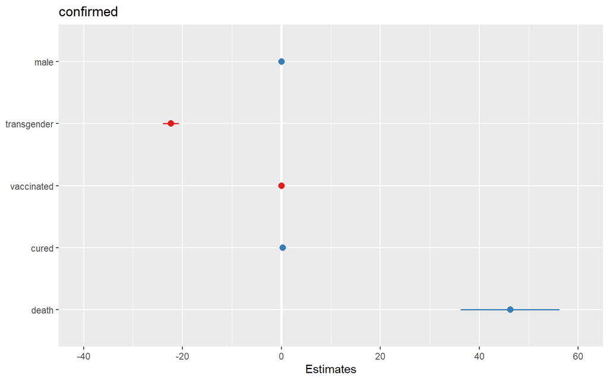

```r
library(sjPlot)
plot_model(fit)
```

# Granger因果检验

```r
library("lmtest")
grangertest(vaccinated,confirmed,order=1)
```

```
## Granger causality test
##
## Model 1: confirmed ~ Lags(confirmed, 1:1) + Lags(vaccinated, 1:1)
## Model 2: confirmed ~ Lags(confirmed, 1:1)
##   Res.Df Df      F    Pr(>F)
## 1    442
## 2    443 -1 20.488 7.726e-06 ***
## ---
## Signif. codes:  0 '***' 0.001 '**' 0.01 '*' 0.05 '.' 0.1 ' ' 1
```

```r
grangertest(confirmed,vaccinated,order=1)
```

```
## Granger causality test
##
## Model 1: vaccinated ~ Lags(vaccinated, 1:1) + Lags(confirmed, 1:1)
## Model 2: vaccinated ~ Lags(vaccinated, 1:1)
##   Res.Df Df      F   Pr(>F)
## 1    442
## 2    443 -1 7.8216 0.005388 **
## ---
## Signif. codes:  0 '***' 0.001 '**' 0.01 '*' 0.05 '.' 0.1 ' ' 1
```

```r
grangertest(transgender,confirmed,order=1)
```

```
## Granger causality test
##
## Model 1: confirmed ~ Lags(confirmed, 1:1) + Lags(transgender, 1:1)
## Model 2: confirmed ~ Lags(confirmed, 1:1)
##   Res.Df Df      F   Pr(>F)
## 1    442
## 2    443 -1 7.9035 0.005153 **
## ---
## Signif. codes:  0 '***' 0.001 '**' 0.01 '*' 0.05 '.' 0.1 ' ' 1
```

```r
grangertest(confirmed,transgender,order=1)
```

```
## Granger causality test
##
## Model 1: transgender ~ Lags(transgender, 1:1) + Lags(confirmed, 1:1)
## Model 2: transgender ~ Lags(transgender, 1:1)
##   Res.Df Df      F    Pr(>F)
## 1    442
## 2    443 -1 48.811 1.042e-11 ***
## ---
## Signif. codes:  0 '***' 0.001 '**' 0.01 '*' 0.05 '.' 0.1 ' ' 1
```

```r
grangertest(confirmed,male,order=1)
```

```
## Granger causality test
##
## Model 1: male ~ Lags(male, 1:1) + Lags(confirmed, 1:1)
## Model 2: male ~ Lags(male, 1:1)
##   Res.Df Df      F    Pr(>F)
## 1    442
## 2    443 -1 62.732 1.937e-14 ***
## ---
## Signif. codes:  0 '***' 0.001 '**' 0.01 '*' 0.05 '.' 0.1 ' ' 1
```

```r
grangertest(male,confirmed,order=1)
```

```
## Granger causality test
##
## Model 1: confirmed ~ Lags(confirmed, 1:1) + Lags(male, 1:1)
## Model 2: confirmed ~ Lags(confirmed, 1:1)
##   Res.Df Df     F  Pr(>F)
## 1    442
## 2    443 -1 2.774 0.09652 .
## ---
## Signif. codes:  0 '***' 0.001 '**' 0.01 '*' 0.05 '.' 0.1 ' ' 1
```

# 新增确诊人数预测

## 最终预测模型

```r
fit3 <- Arima(confirmed,xreg = as.matrix(data.frame(cured,death,vaccinated)),order = c(3,1,5),seasonal=list(order=c(1,1,1),period=7));fit3
```

```
## Series: confirmed
## Regression with ARIMA(3,1,5)(1,1,1)[7] errors
##
## Coefficients:
##          ar1      ar2     ar3      ma1     ma2      ma3     ma4     ma5
##       1.9132  -1.8083  0.8006  -2.1742  2.4858  -1.4972  0.3837  0.1006
## s.e.  0.0556   0.0878  0.0562   0.0768  0.1656   0.1953  0.1416  0.0642
##          sar1     sma1   cured   death  vaccinated
##       -0.3129  -0.5926  0.1716  4.6812      -2e-04
## s.e.   0.0936   0.0787  0.0347  1.6255       4e-04
##
## sigma^2 estimated as 32120576:  log likelihood=-4402.59
## AIC=8833.18   AICc=8834.17   BIC=8890.33
```

```r
fit4 <- Arima(confirmed,xreg = as.matrix(data.frame( male,transgender,cured,death,vaccinated)),order = c(3,1,5),seasonal=list(order=c(1,1,1),period=7));fit4
```

```
## Series: confirmed
## Regression with ARIMA(3,1,5)(1,1,1)[7] errors
##
## Coefficients:
##          ar1      ar2     ar3      ma1     ma2      ma3     ma4     ma5
##       1.9078  -1.8047  0.7972  -2.1671  2.4705  -1.4732  0.3686  0.1086
## s.e.  0.0571   0.0892  0.0580   0.0776  0.1668   0.1958  0.1417  0.0640
##          sar1     sma1    male  transgender   cured   death  vaccinated
##       -0.3116  -0.5988  0.0008      -2.4457  0.1721  4.8988      -2e-04
## s.e.   0.0940   0.0781  0.0011       2.5430  0.0349  1.6440       5e-04
##
## sigma^2 estimated as 32194949:  log likelihood=-4402.12
## AIC=8836.25   AICc=8837.54   BIC=8901.56
```

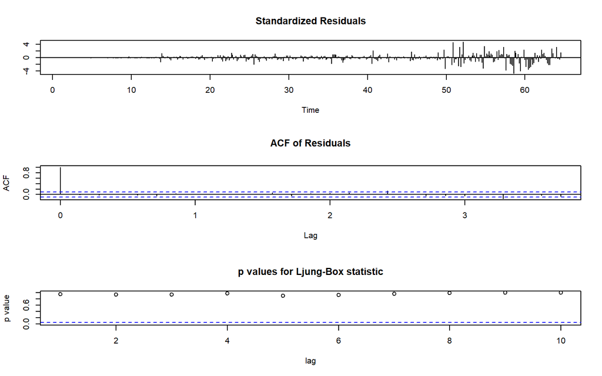

```r
tsdiag(fit3)
```

模型通过显著性检验。

## 预测效果验证

```r
mape <- vector()
smape <- vector()
for(i in 4:1){
print(c((438+2*i-1):(438+2*i)))
fit3.1 <- Arima(confirmed[-c((438+2*i-1):(438+2*i))],xreg = as.matrix(data.frame(cured[-c((438+2*i-1):(438+2*i))],death[-c((438+2*i-1):(438+2*i))],vaccinated[-c((438+2*i-1):(438+2*i))])),order = c(3,1,5),seasonal=list(order=c(1,1,1),period=7))
x <- as.matrix(data.frame(cured=cured[c((438+2*i-1):(438+2*i))],death=death[c((438+2*i-1):(438+2*i))],vaccinated=vaccinated[c((438+2*i-1):(438+2*i))]))
forenew<-forecast::forecast(fit3,xreg=x,h=7);forenew
#平均绝对百分比误差(MAPE, Mean Absolute Percentage Error)
mape <- c(mape,mean(abs((forenew$mean-confirmed[c((438+2*i-1):(438+2*i))]))/confirmed[c((438+2*i-1):(438+2*i))]))
print(mean(abs((forenew$mean-confirmed[c((438+2*i-1):(438+2*i))]))/confirmed[c((438+2*i-1):(438+2*i))]))
#SMAPE
smape <- c(smape,2*(mean(abs(forenew$mean-confirmed[c((438+2*i-1):(438+2*i))])/(abs(forenew$mean)+abs(confirmed[c((438+2*i-1):(438+2*i))])))))
print(2*(mean(abs(forenew$mean-confirmed[c((438+2*i-1):(438+2*i))])/(abs(forenew$mean)+abs(confirmed[c((438+2*i-1):(438+2*i))])))))
}
```

```
## [1] 445 446
## [1] 0.1424568
## [1] 0.1292135
## [1] 443 444
## [1] 0.07844178
## [1] 0.08326973
## [1] 441 442
## [1] 0.1739555
## [1] 0.1917294
## [1] 439 440
## [1] 0.1024404
## [1] 0.1081794
```

```r
cat("MAPE",mean(mape))
```

```
## MAPE 0.1243236
```

```r
cat(" SMAPE",mean(smape))
```

```
##  SMAPE 0.128098
```

关注到交叉验证计算的MAPE和SMAPE均小于0.2，且均值均为0.12左右，说明模型的预测效果不错。

## 拟合治愈人数序列

```r
par(mfrow=c(1,2))
adf.test(diff(diff(cured,7)))
```

```
## Augmented Dickey-Fuller Test
## alternative: stationary
##
## Type 1: no drift no trend
##      lag    ADF p.value
## [1,]   0 -27.19    0.01
## [2,]   1 -20.53    0.01
## [3,]   2 -13.95    0.01
## [4,]   3 -10.85    0.01
## [5,]   4  -8.73    0.01
## [6,]   5  -7.12    0.01
## Type 2: with drift no trend
##      lag    ADF p.value
## [1,]   0 -27.17    0.01
## [2,]   1 -20.52    0.01
## [3,]   2 -13.95    0.01
## [4,]   3 -10.85    0.01
## [5,]   4  -8.73    0.01
## [6,]   5  -7.12    0.01
## Type 3: with drift and trend
##      lag    ADF p.value
## [1,]   0 -27.18    0.01
## [2,]   1 -20.56    0.01
## [3,]   2 -13.99    0.01
## [4,]   3 -10.89    0.01
## [5,]   4  -8.78    0.01
## [6,]   5  -7.17    0.01
## ----
## Note: in fact, p.value = 0.01 means p.value <= 0.01
```

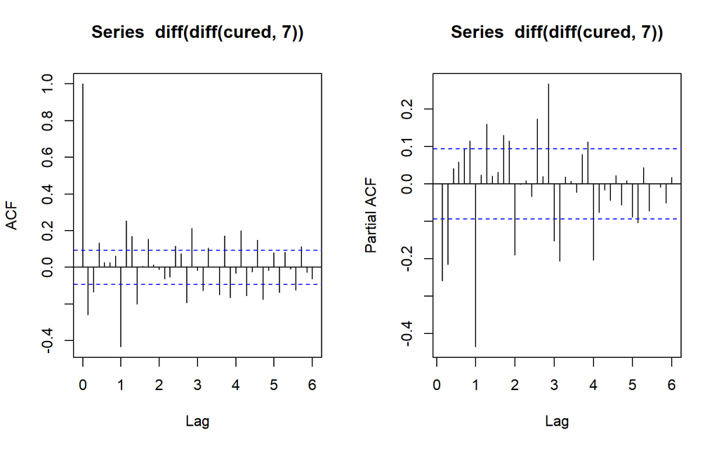

```r
acf(diff(diff(cured,7)),lag=42)
pacf(diff(diff(cured,7)),lag=42)
```

趋势：acf拖尾，pacf拖尾——ARIMA(1,1,1)

季节：acf拖尾，pacf拖尾——ARIMA(1,1,1)

```r
#通过观察系数A和模型显著性，对模型进行升阶改进，最终选择如下模型：
fitc <- Arima(cured,order = c(3,1,2),seasonal=list(order=c(1,1,1),period=7));fitc
```

```
## Series: cured
## ARIMA(3,1,2)(1,1,1)[7]
##
## Coefficients:
##         ar1      ar2     ar3      ma1     ma2    sar1     sma1
##       0.903  -0.0656  0.1224  -1.1672  0.3215  0.0632  -0.8544
## s.e.  0.252   0.1579  0.1051   0.2534  0.2150  0.0758   0.0495
##
## sigma^2 estimated as 54874153:  log likelihood=-4524.37
## AIC=9064.75   AICc=9065.08   BIC=9097.41
```

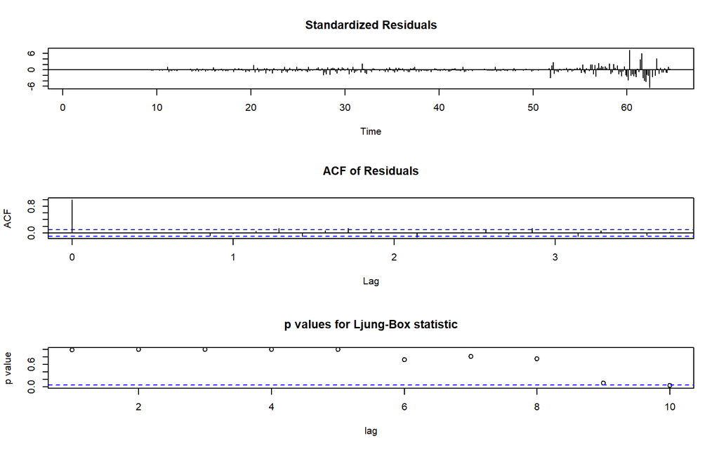

```r
tsdiag(fitc)
```

```r
forec <- forecast::forecast(fitc,h=5);forec
```

```
##          Point Forecast    Lo 80    Hi 80    Lo 95    Hi 95
## 64.71429       162013.2 152519.9 171506.6 147494.4 176532.1
## 64.85714       146777.6 134991.2 158563.9 128751.9 164803.2
## 65.00000       138670.0 124884.6 152455.5 117587.0 159753.0
## 65.14286       134345.0 118083.6 150606.3 109475.4 159214.6
## 65.28571       131221.3 112317.5 150125.1 102310.4 160132.2
```

## 拟合死亡人数序列

```r
par(mfrow=c(1,2))
adf.test(diff(diff(death,7)))
```

```
## Augmented Dickey-Fuller Test
## alternative: stationary
##
## Type 1: no drift no trend
##      lag    ADF p.value
## [1,]   0 -35.14    0.01
## [2,]   1 -24.99    0.01
## [3,]   2 -17.98    0.01
## [4,]   3 -15.88    0.01
## [5,]   4 -13.63    0.01
## [6,]   5  -7.85    0.01
## Type 2: with drift no trend
##      lag    ADF p.value
## [1,]   0 -35.10    0.01
## [2,]   1 -24.97    0.01
## [3,]   2 -17.97    0.01
## [4,]   3 -15.87    0.01
## [5,]   4 -13.63    0.01
## [6,]   5  -7.84    0.01
## Type 3: with drift and trend
##      lag    ADF p.value
## [1,]   0 -35.08    0.01
## [2,]   1 -24.96    0.01
## [3,]   2 -17.98    0.01
## [4,]   3 -15.90    0.01
## [5,]   4 -13.66    0.01
## [6,]   5  -7.86    0.01
## ----
## Note: in fact, p.value = 0.01 means p.value <= 0.01
```

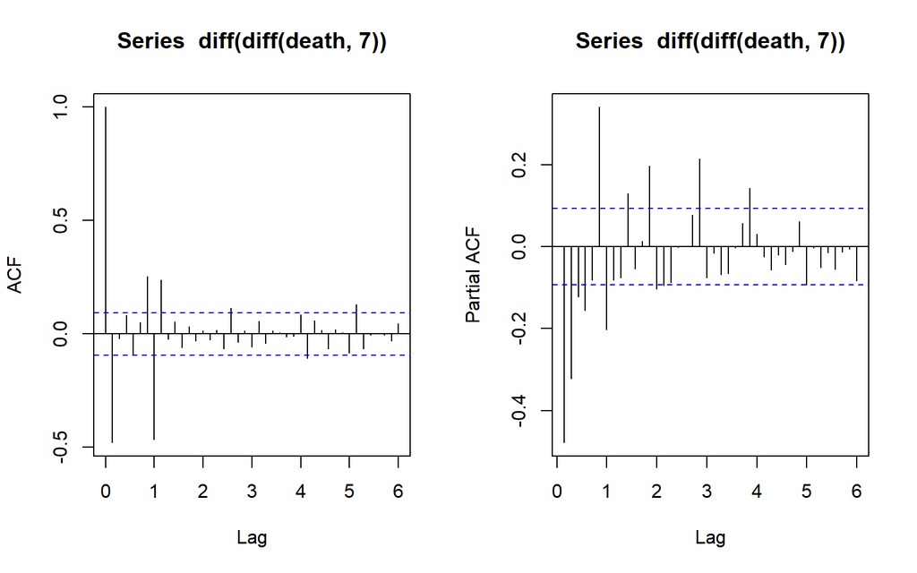

```r
acf(diff(diff(death,7)),lag=42)
pacf(diff(diff(death,7)),lag=42)
```

趋势：acf拖尾，pacf拖尾——ARIMA(1,1,1)

季节：acf一阶截尾，pacf拖尾——ARIMA(0,1,1)

```r
#通过观察系数显著性，对模型进行升阶改进，最终选择如下模型：
fitd <- Arima(death,order = c(1,1,2),seasonal=list(order=c(0,1,1),period=7));fitd
```

```
## Series: death
## ARIMA(1,1,2)(0,1,1)[7]
##
## Coefficients:
##          ar1      ma1     ma2     sma1
##       0.9594  -1.5938  0.6872  -0.9362
## s.e.  0.0234   0.0374  0.0371   0.0391
##
## sigma^2 estimated as 20873:  log likelihood=-2804.34
## AIC=5618.69   AICc=5618.83   BIC=5639.1
```

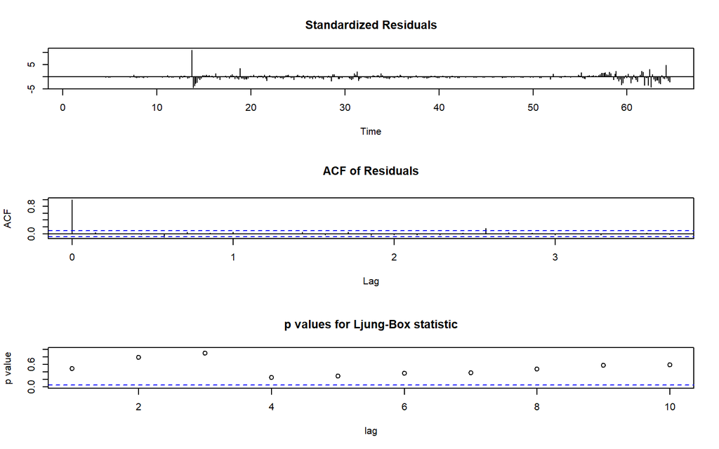

```r
tsdiag(fitd)
```

```r
fored <- forecast::forecast(fitd,h=5);fored
```

```
##          Point Forecast    Lo 80    Hi 80    Lo 95    Hi 95
## 64.71429       2400.519 2215.364 2585.673 2117.350 2683.688
## 64.85714       2234.418 2037.283 2431.554 1932.925 2535.911
## 65.00000       2124.527 1910.932 2338.122 1797.862 2451.193
## 65.14286       2097.363 1863.114 2331.613 1739.110 2455.617
## 65.28571       1927.041 1668.436 2185.646 1531.539 2322.543
```

## 拟合注射疫苗人数序列

```r
par(mfrow=c(1,2))
adf.test(diff(vaccinated,7))
```

```
## Augmented Dickey-Fuller Test
## alternative: stationary
##
## Type 1: no drift no trend
##      lag    ADF p.value
## [1,]   0 -13.10    0.01
## [2,]   1  -7.81    0.01
## [3,]   2  -5.91    0.01
## [4,]   3  -6.18    0.01
## [5,]   4  -6.01    0.01
## [6,]   5  -6.94    0.01
## Type 2: with drift no trend
##      lag    ADF p.value
## [1,]   0 -13.16    0.01
## [2,]   1  -7.86    0.01
## [3,]   2  -5.96    0.01
## [4,]   3  -6.23    0.01
## [5,]   4  -6.06    0.01
## [6,]   5  -7.00    0.01
## Type 3: with drift and trend
##      lag    ADF p.value
## [1,]   0 -13.26    0.01
## [2,]   1  -7.93    0.01
## [3,]   2  -6.03    0.01
## [4,]   3  -6.30    0.01
## [5,]   4  -6.14    0.01
## [6,]   5  -7.09    0.01
## ----
## Note: in fact, p.value = 0.01 means p.value <= 0.01
```

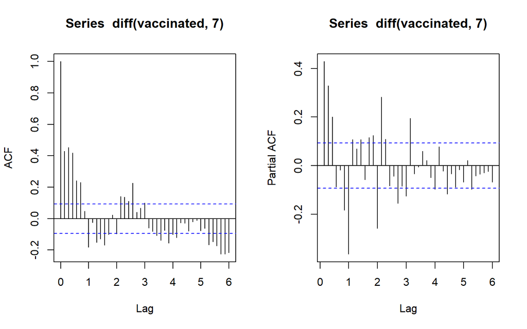

```r
acf(diff(vaccinated,7),lag=42)
pacf(diff(vaccinated,7),lag=42)
```

趋势：acf拖尾，pacf拖尾——ARIMA(1,0,1)

季节：acf拖尾，pacf拖尾——ARIMA(1,1,1)

```r
#通过观察系数显著性，对模型进行升阶改进，最终选择如下模型：
fitv <- Arima(vaccinated,order = c(1,0,2),seasonal=list(order=c(1,1,1),period=7),include.drift = T);fitv
```

```
## Series: vaccinated
## ARIMA(1,0,2)(1,1,1)[7] with drift
##
## Coefficients:
##          ar1      ma1     ma2    sar1     sma1      drift
##       0.9391  -0.6713  0.1948  0.0892  -0.8404  10660.628
## s.e.  0.0217   0.0507  0.0491  0.0584   0.0316   6987.633
##
## sigma^2 estimated as 4.216e+11:  log likelihood=-6499.05
## AIC=13012.11   AICc=13012.37   BIC=13040.7
```

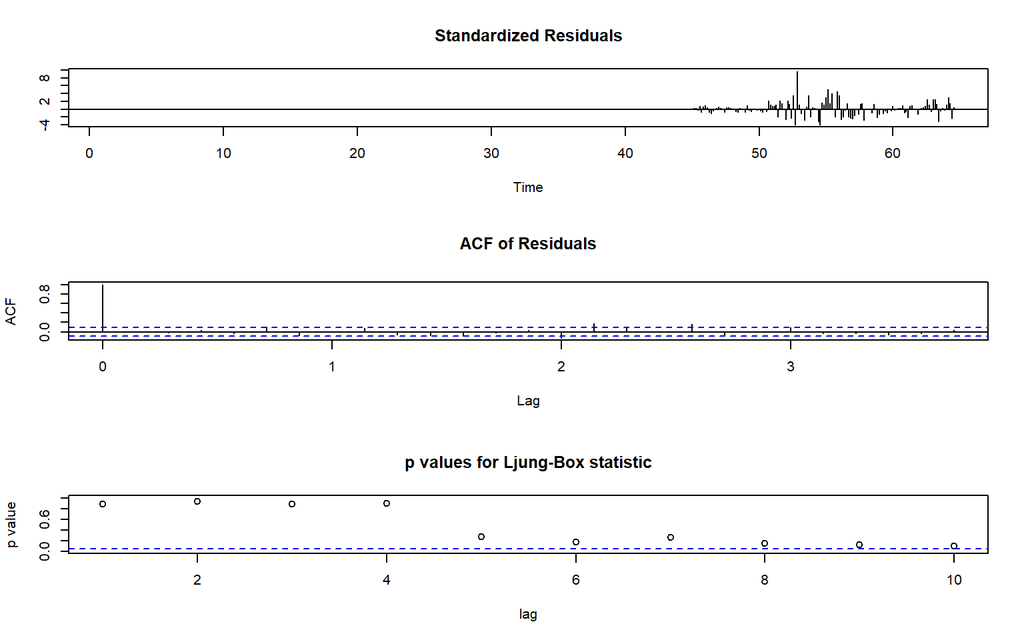

```r
tsdiag(fitv)
```

```r
forev <- forecast::forecast(fitv,h=5);forev
```

```
##          Point Forecast   Lo 80   Hi 80   Lo 95   Hi 95
## 64.71429        5117291 4285172 5949410 3844674 6389907
## 64.85714        5312139 4450700 6173578 3994681 6629597
## 65.00000        5729144 4791056 6667231 4294463 7163825
## 65.14286        6035221 5034396 7036045 4504592 7565849
## 65.28571        5672458 4619403 6725513 4061949 7282966
```

## 预测新增确诊人数

```r
forexnew <- as.matrix(data.frame(cured=forec$mean,death=fored$mean,vaccinated=forev$mean))
forenew<-forecast::forecast(fit3,xreg=forexnew,h=5);forenew
```

```
##          Point Forecast    Lo 80    Hi 80    Lo 95    Hi 95
## 64.71429       94194.35 86931.15 101457.5 83086.25 105302.4
## 64.85714      102471.61 93440.01 111503.2 88658.96 116284.3
## 65.00000       91802.43 80579.17 103025.7 74637.93 108966.9
## 65.14286       87583.60 74081.15 101086.1 66933.39 108233.8
## 65.28571       84812.26 69091.72 100532.8 60769.78 108854.7
```

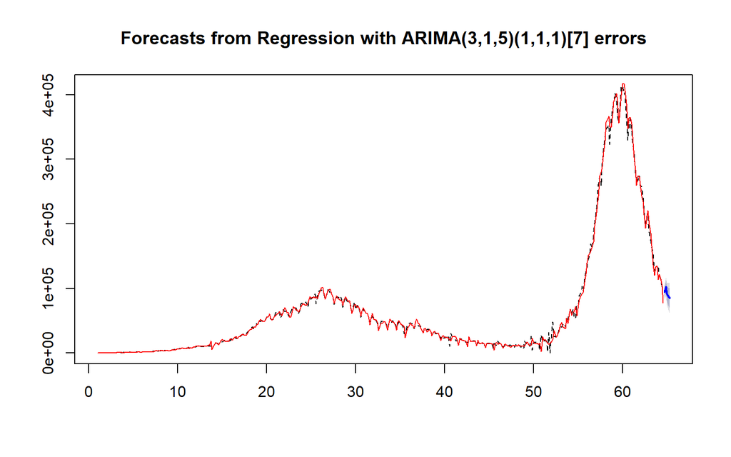

```r
plot(forenew,lty=2)
lines(forenew$fitted,col=2)
```